# Innovation Success Prediction - Supervised Learning

**Business Question:** Which innovations will succeed in the market?

**Dataset:** 6,000 technology innovations (2020-2024)

**Goal:** Train classifiers to predict innovation success based on company, market, and innovation features.

**Approach:** Compare Random Forest, Logistic Regression, and XGBoost to understand when different algorithms excel.

## What is Supervised Learning?

**Supervised Learning** is a machine learning approach where we train models using **labeled data** - data where we already know the correct answer (the "label" or "target").

**Key Concepts:**

- **Features (X):** Input variables that describe each innovation (company age, funding, team size, etc.)
- **Target (y):** The outcome we want to predict (success = 1, failure = 0)
- **Training:** Model learns patterns from labeled examples
- **Prediction:** Apply learned patterns to predict outcomes for new innovations

**Why Supervised Learning?**

- We have historical data with known outcomes
- We want to predict future outcomes
- We need quantifiable accuracy metrics
- We want to understand which factors drive success

## Functions

```python
import pandas as pd
import numpy as np
import matplotlib.pyplot as plt
import seaborn as sns
from sklearn.model_selection import train_test_split, learning_curve, validation_curve
from sklearn.ensemble import RandomForestClassifier
from sklearn.linear_model import LogisticRegression
from sklearn.preprocessing import StandardScaler
from sklearn.metrics import (
    classification_report, accuracy_score, precision_score, recall_score,
    f1_score, roc_auc_score, confusion_matrix, roc_curve, precision_recall_curve, auc
)
import warnings
warnings.filterwarnings('ignore')

try:
    from xgboost import XGBClassifier
    XGBOOST_AVAILABLE = True
except ImportError:
    XGBOOST_AVAILABLE = False
    print("XGBoost not available. Install with: pip install xgboost")


# ============================================================================
# DATA LOADING AND EXPLORATION FUNCTIONS
# ============================================================================

def load_and_explore_data(filepath='innovations.csv'):
    """Load dataset and display basic information."""
    df = pd.read_csv(filepath)

    print("=" * 80)
    print("DATASET OVERVIEW")
    print("=" * 80)
    print(f"\nShape: {df.shape[0]} innovations, {df.shape[1]} columns")
    print(f"\nColumns: {list(df.columns)}")
    print(f"\nMissing values: {df.isnull().sum().sum()}")
    print(f"\nSuccess rate: {df['success'].mean():.1%}")
    print(f"  Successful: {df['success'].sum():,}")
    print(f"  Failed: {(df['success'] == 0).sum():,}")
    print("\n" + "=" * 80 + "\n")

    return df


def plot_target_distribution(df):
    """Visualize target variable distribution."""
    fig, axes = plt.subplots(1, 2, figsize=(14, 5))

    # Count plot
    counts = df['success'].value_counts().sort_index()
    colors = ['red', 'green']
    bars = axes[0].bar(['Failed (0)', 'Success (1)'], counts.values,
                       color=colors, alpha=0.7, edgecolor='black', linewidth=1.5)
    axes[0].set_ylabel('Count', fontsize=11)
    axes[0].set_title('Target Distribution: Success vs Failure', fontsize=12, fontweight='bold')
    axes[0].grid(axis='y', alpha=0.3)

    # Add count labels
    for bar, count in zip(bars, counts.values):
        height = bar.get_height()
        axes[0].text(bar.get_x() + bar.get_width()/2., height,
                    f'{count:,}\n({count/len(df):.1%})',
                    ha='center', va='bottom', fontsize=10, fontweight='bold')

    # Percentage pie chart
    axes[1].pie(counts.values, labels=['Failed', 'Success'], autopct='%1.1f%%',
               colors=colors, startangle=90, textprops={'fontsize': 11, 'fontweight': 'bold'})
    axes[1].set_title('Success Rate Distribution', fontsize=12, fontweight='bold')

    plt.tight_layout()
    plt.show()

    print("\n💡 What This Chart Tells Us:")
    print(f"   - Dataset is relatively balanced ({df['success'].mean():.1%} success rate)")
    print(f"   - Not severely imbalanced, so accuracy is a reasonable metric")
    print(f"   - Baseline (always predict majority class) = {max(df['success'].mean(), 1-df['success'].mean()):.1%}")
    print(f"   - Our model must beat this baseline to be useful\n")


def analyze_feature_distributions(df):
    """Analyze numerical feature distributions by target class."""
    numerical_features = ['company_age_years', 'team_size', 'team_experience_avg_years',
                         'funding_raised_usd', 'market_size_millions', 'market_growth_rate']

    fig, axes = plt.subplots(2, 3, figsize=(16, 10))
    axes = axes.flatten()

    for idx, feature in enumerate(numerical_features):
        successful = df[df['success'] == 1][feature]
        failed = df[df['success'] == 0][feature]

        axes[idx].hist([failed, successful], bins=30, label=['Failed', 'Success'],
                      color=['red', 'green'], alpha=0.6, edgecolor='black')
        axes[idx].set_xlabel(feature.replace('_', ' ').title(), fontsize=10)
        axes[idx].set_ylabel('Frequency', fontsize=10)
        axes[idx].set_title(f'{feature.replace("_", " ").title()} Distribution',
                           fontsize=11, fontweight='bold')
        axes[idx].legend()
        axes[idx].grid(axis='y', alpha=0.3)

        # Add mean lines
        axes[idx].axvline(successful.mean(), color='green', linestyle='--', linewidth=2, alpha=0.7)
        axes[idx].axvline(failed.mean(), color='red', linestyle='--', linewidth=2, alpha=0.7)

    plt.tight_layout()
    plt.show()

    print("\n💡 What This Chart Tells Us:")
    print("   - Green = successful innovations, Red = failed innovations")
    print("   - Dashed lines show mean values for each class")
    print("   - Look for separation between red and green distributions")
    print("   - Better separation = feature is more predictive\n")


def plot_correlation_heatmap(df, feature_cols):
    """Plot correlation heatmap of features with target."""
    # Select numerical features + target
    numerical_cols = [col for col in feature_cols if df[col].dtype in ['int64', 'float64']]
    corr_data = df[numerical_cols + ['success']].corr()

    # Plot heatmap
    plt.figure(figsize=(12, 10))
    sns.heatmap(corr_data, annot=True, fmt='.2f', cmap='coolwarm', center=0,
               square=True, linewidths=1, cbar_kws={'label': 'Correlation'})
    plt.title('Feature Correlation Heatmap (with Target)', fontsize=12, fontweight='bold')
    plt.tight_layout()
    plt.show()

    # Print top correlations with target
    target_corr = corr_data['success'].drop('success').sort_values(ascending=False)
    print("\n💡 Top Correlations with Success:")
    print(target_corr.head(5))
    print("\n💡 Negative Correlations (inverse relationship):")
    print(target_corr.tail(5))
    print("\n   - Positive correlation: higher value → higher success probability")
    print("   - Negative correlation: higher value → lower success probability\n")


# ============================================================================
# FEATURE ENGINEERING FUNCTIONS
# ============================================================================
```

```python
def prepare_features(df):
    """Prepare features for modeling by encoding categorical variables."""
    df_prep = df.copy()

    print("Feature Engineering Steps:")
    print("-" * 40)

    # Numerical features
    numerical_features = [
        'company_age_years', 'team_size', 'team_experience_avg_years',
        'has_prior_success', 'funding_raised_usd', 'market_size_millions',
        'market_growth_rate'
    ]
    print(f"✓ Using {len(numerical_features)} numerical features")

    # Encode categorical variables (one-hot encoding)
    df_prep['company_type_encoded'] = (df_prep['company_type'] == 'Corporate').astype(int)
    df_prep['competition_low'] = (df_prep['competition_level'] == 'Low').astype(int)
    df_prep['competition_high'] = (df_prep['competition_level'] == 'High').astype(int)
    df_prep['stage_scaling'] = (df_prep['development_stage'] == 'Scaling').astype(int)
    df_prep['stage_market_ready'] = (df_prep['development_stage'] == 'Market-Ready').astype(int)
    print(f"✓ Encoded 3 categorical variables → 5 binary features")

    # All feature columns
    feature_cols = numerical_features + [
        'company_type_encoded', 'competition_low', 'competition_high',
        'stage_scaling', 'stage_market_ready'
    ]

    X = df_prep[feature_cols]
    y = df_prep['success']

    print(f"\n✓ Total features: {len(feature_cols)}")
    print(f"✓ Samples: {len(X):,}\n")

    return X, y, feature_cols, df_prep


def split_data(X, y, test_size=0.2, random_state=42):
    """Split data into training and test sets with stratification."""
    X_train, X_test, y_train, y_test = train_test_split(
        X, y, test_size=test_size, random_state=random_state, stratify=y
    )

    print("Data Split:")
    print("-" * 40)
    print(f"Training set: {len(X_train):,} samples ({len(X_train)/len(X):.0%})")
    print(f"Test set: {len(X_test):,} samples ({len(X_test)/len(X):.0%})")
    print(f"\nTraining success rate: {y_train.mean():.1%}")
    print(f"Test success rate: {y_test.mean():.1%}")
    print(f"\n✓ Stratified split maintains class balance\n")

    return X_train, X_test, y_train, y_test


# ============================================================================
# MODEL TRAINING FUNCTIONS
# ============================================================================

def train_random_forest(X_train, y_train, n_estimators=100, max_depth=10, random_state=42):
    """Train Random Forest classifier."""
    print("Training Random Forest...")
    print("-" * 40)
    print(f"Parameters: n_estimators={n_estimators}, max_depth={max_depth}")

    model = RandomForestClassifier(
        n_estimators=n_estimators,
        max_depth=max_depth,
        random_state=random_state,
        n_jobs=-1
    )
    model.fit(X_train, y_train)

    print(f"✓ Model trained successfully\n")
    return model


def train_logistic_regression(X_train, y_train, random_state=42):
    """Train Logistic Regression as baseline."""
    print("Training Logistic Regression (Baseline)...")
    print("-" * 40)

    # Scale features for logistic regression
    scaler = StandardScaler()
    X_train_scaled = scaler.fit_transform(X_train)

    model = LogisticRegression(random_state=random_state, max_iter=1000)
    model.fit(X_train_scaled, y_train)

    print(f"✓ Model trained successfully\n")
    return model, scaler


def train_xgboost(X_train, y_train, random_state=42):
    """Train XGBoost classifier."""
    if not XGBOOST_AVAILABLE:
        print("XGBoost not available. Skipping.\n")
        return None

    print("Training XGBoost...")
    print("-" * 40)
    print(f"Parameters: n_estimators=100, max_depth=6, learning_rate=0.1")

    model = XGBClassifier(
        n_estimators=100,
        max_depth=6,
        learning_rate=0.1,
        random_state=random_state,
        eval_metric='logloss'
    )
    model.fit(X_train, y_train)

    print(f"✓ Model trained successfully\n")
    return model


# ============================================================================
# MODEL EVALUATION FUNCTIONS
# ============================================================================

def evaluate_model(model, X_test, y_test, model_name='Model', scaler=None):
    """Comprehensive model evaluation with all metrics."""
    # Scale if needed
    X_test_eval = scaler.transform(X_test) if scaler is not None else X_test

    # Predictions
    y_pred = model.predict(X_test_eval)
    y_pred_proba = model.predict_proba(X_test_eval)[:, 1]

    # Calculate metrics
    accuracy = accuracy_score(y_test, y_pred)
    precision = precision_score(y_test, y_pred)
    recall = recall_score(y_test, y_pred)
    f1 = f1_score(y_test, y_pred)
    roc_auc = roc_auc_score(y_test, y_pred_proba)

    print("=" * 80)
    print(f"{model_name.upper()} PERFORMANCE")
    print("=" * 80)
    print(f"\nAccuracy:  {accuracy:.1%}  (correct predictions / total predictions)")
    print(f"Precision: {precision:.1%}  (true positives / predicted positives)")
    print(f"Recall:    {recall:.1%}  (true positives / actual positives)")
    print(f"F1-Score:  {f1:.1%}  (harmonic mean of precision and recall)")
    print(f"ROC-AUC:   {roc_auc:.3f}  (area under ROC curve, 0.5=random, 1.0=perfect)")
    print(f"\nClassification Report:")
    print(classification_report(y_test, y_pred, target_names=['Failed', 'Success']))
    print("=" * 80 + "\n")

    return {
        'predictions': y_pred,
        'probabilities': y_pred_proba,
        'accuracy': accuracy,
        'precision': precision,
        'recall': recall,
        'f1': f1,
        'roc_auc': roc_auc
    }


def plot_confusion_matrix(y_test, y_pred, model_name='Model'):
    """Plot enhanced confusion matrix with percentages."""
    cm = confusion_matrix(y_test, y_pred)
    cm_percent = cm.astype('float') / cm.sum(axis=1)[:, np.newaxis] * 100

    fig, axes = plt.subplots(1, 2, figsize=(14, 5))

    # Absolute counts
    sns.heatmap(cm, annot=True, fmt='d', cmap='Blues',
               xticklabels=['Predicted Failed', 'Predicted Success'],
               yticklabels=['Actual Failed', 'Actual Success'],
               ax=axes[0], cbar_kws={'label': 'Count'})
    axes[0].set_title(f'{model_name} - Confusion Matrix (Counts)', fontsize=12, fontweight='bold')
```

```python
    # Percentages
    sns.heatmap(cm_percent, annot=True, fmt='.1f', cmap='Greens',
               xticklabels=['Predicted Failed', 'Predicted Success'],
               yticklabels=['Actual Failed', 'Actual Success'],
               ax=axes[1], cbar_kws={'label': 'Percentage (%)'})
    axes[1].set_title(f'{model_name} - Confusion Matrix (Row %)', fontsize=12, fontweight='bold')

    plt.tight_layout()
    plt.show()

    print("\n💡 Confusion Matrix Interpretation:")
    print(f"   - True Negatives (TN): {cm[0,0]:,} - Correctly predicted failures")
    print(f"   - False Positives (FP): {cm[0,1]:,} - Predicted success, actually failed")
    print(f"   - False Negatives (FN): {cm[1,0]:,} - Predicted failure, actually succeeded")
    print(f"   - True Positives (TP): {cm[1,1]:,} - Correctly predicted successes\n")


def plot_roc_curves(models_data, y_test):
    """Plot ROC curves for multiple models."""
    plt.figure(figsize=(10, 8))

    colors = ['blue', 'green', 'red', 'purple']

    for (name, results), color in zip(models_data.items(), colors):
        fpr, tpr, _ = roc_curve(y_test, results['probabilities'])
        roc_auc = results['roc_auc']

        plt.plot(fpr, tpr, label=f'{name} (AUC = {roc_auc:.3f})',
                linewidth=2, color=color)

    plt.plot([0, 1], [0, 1], 'k--', label='Random Guess (AUC = 0.500)', linewidth=1)
    plt.xlabel('False Positive Rate', fontsize=11)
    plt.ylabel('True Positive Rate', fontsize=11)
    plt.title('ROC Curves: Model Comparison', fontsize=12, fontweight='bold')
    plt.legend(loc='lower right', fontsize=10)
    plt.grid(alpha=0.3)
    plt.tight_layout()
    plt.show()

    print("\n💡 ROC Curve Interpretation:")
    print("   - ROC = Receiver Operating Characteristic")
    print("   - Shows tradeoff between True Positive Rate and False Positive Rate")
    print("   - AUC (Area Under Curve) = overall model quality metric")
    print("   - AUC = 0.5: Random guessing | AUC = 1.0: Perfect classifier")
    print("   - Higher curve = better model\n")


def plot_precision_recall_curves(models_data, y_test):
    """Plot Precision-Recall curves for multiple models."""
    plt.figure(figsize=(10, 8))

    colors = ['blue', 'green', 'red', 'purple']

    for (name, results), color in zip(models_data.items(), colors):
        precision, recall, _ = precision_recall_curve(y_test, results['probabilities'])
        pr_auc = auc(recall, precision)

        plt.plot(recall, precision, label=f'{name} (AUC = {pr_auc:.3f})',
                linewidth=2, color=color)

    baseline = y_test.mean()
    plt.axhline(y=baseline, color='k', linestyle='--',
               label=f'Baseline (No Skill = {baseline:.3f})', linewidth=1)

    plt.xlabel('Recall (Sensitivity)', fontsize=11)
    plt.ylabel('Precision', fontsize=11)
    plt.title('Precision-Recall Curves: Model Comparison', fontsize=12, fontweight='bold')
    plt.legend(loc='best', fontsize=10)
    plt.grid(alpha=0.3)
    plt.tight_layout()
    plt.show()

    print("\n💡 Precision-Recall Curve Interpretation:")
    print("   - Useful for imbalanced datasets")
    print("   - Precision: Of predicted successes, how many were correct?")
    print("   - Recall: Of actual successes, how many did we find?")
    print("   - Higher curve = better model\n")


def plot_feature_importance(model, feature_cols, top_n=15):
    """Plot feature importance for tree-based models."""
    if not hasattr(model, 'feature_importances_'):
        print("Model does not have feature_importances_ attribute\n")
        return

    # Get importance
    importances = pd.DataFrame({
        'feature': feature_cols,
        'importance': model.feature_importances_
    }).sort_values('importance', ascending=False)

    # Plot
    plt.figure(figsize=(12, 8))
    top_features = importances.head(top_n)
    colors = plt.cm.viridis(np.linspace(0.3, 0.9, len(top_features)))

    plt.barh(range(len(top_features)), top_features['importance'].values, color=colors)
    plt.yticks(range(len(top_features)),
              [f.replace('_', ' ').title() for f in top_features['feature'].values])
    plt.xlabel('Importance Score', fontsize=11)
    plt.title(f'Top {top_n} Feature Importance (Random Forest)', fontsize=12, fontweight='bold')
    plt.gca().invert_yaxis()
    plt.grid(axis='x', alpha=0.3)
    plt.tight_layout()
    plt.show()

    print("\n💡 Top 10 Most Important Features:")
    for idx, row in importances.head(10).iterrows():
        print(f"   {row['feature']:30s} {row['importance']:.4f}")

    print("\n💡 Feature Importance Interpretation:")
    print("   - Higher importance = feature contributes more to predictions")
    print("   - Based on reduction in impurity (Gini) at each split")
    print("   - Sum of all importances = 1.0\n")

    return importances


def plot_learning_curves(model, X, y, model_name='Model'):
    """Plot learning curves to diagnose bias/variance."""
    train_sizes, train_scores, val_scores = learning_curve(
        model, X, y, cv=5, n_jobs=-1,
        train_sizes=np.linspace(0.1, 1.0, 10),
        scoring='accuracy', random_state=42
    )

    train_mean = train_scores.mean(axis=1)
    train_std = train_scores.std(axis=1)
    val_mean = val_scores.mean(axis=1)
    val_std = val_scores.std(axis=1)

    plt.figure(figsize=(10, 6))
    plt.plot(train_sizes, train_mean, label='Training Score', marker='o', linewidth=2, color='blue')
    plt.fill_between(train_sizes, train_mean - train_std, train_mean + train_std, alpha=0.2, color='blue')

    plt.plot(train_sizes, val_mean, label='Validation Score (CV)', marker='s', linewidth=2, color='green')
    plt.fill_between(train_sizes, val_mean - val_std, val_mean + val_std, alpha=0.2, color='green')

    plt.xlabel('Training Set Size', fontsize=11)
    plt.ylabel('Accuracy', fontsize=11)
    plt.title(f'Learning Curves: {model_name}', fontsize=12, fontweight='bold')
    plt.legend(loc='best')
    plt.grid(alpha=0.3)
    plt.tight_layout()
    plt.show()

    print("\n💡 Learning Curve Interpretation:")
    print("   - Training score > Validation score → Overfitting (memorizing training data)")
    print("   - Both scores low → Underfitting (model too simple)")
    print("   - Curves converge → Good fit")
    print("   - More data helps when curves haven't plateaued\n")
```

```python
def compare_models_metrics(models_data):
    """Create bar chart comparing all model metrics."""
    metrics = ['accuracy', 'precision', 'recall', 'f1', 'roc_auc']
    model_names = list(models_data.keys())

    fig, axes = plt.subplots(1, len(metrics), figsize=(18, 5))

    for idx, metric in enumerate(metrics):
        values = [models_data[name][metric] for name in model_names]
        colors = ['blue', 'green', 'red'][:len(model_names)]

        bars = axes[idx].bar(model_names, values, color=colors, alpha=0.7, edgecolor='black')
        axes[idx].set_ylabel('Score', fontsize=10)
        axes[idx].set_title(metric.replace('_', ' ').title(), fontsize=11, fontweight='bold')
        axes[idx].set_ylim(0, 1)
        axes[idx].grid(axis='y', alpha=0.3)
        axes[idx].tick_params(axis='x', rotation=45)

        # Add value labels
        for bar, val in zip(bars, values):
            height = bar.get_height()
            axes[idx].text(bar.get_x() + bar.get_width()/2., height,
                          f'{val:.3f}', ha='center', va='bottom', fontsize=9, fontweight='bold')

    plt.tight_layout()
    plt.show()

    print("\n💡 Model Comparison Summary:")
    for name in model_names:
        print(f"\n{name}:")
        for metric in metrics:
            print(f"  {metric:12s}: {models_data[name][metric]:.3f}")
    print()


def plot_prediction_distributions(models_data, y_test):
    """Plot probability distributions for predicted classes."""
    n_models = len(models_data)
    fig, axes = plt.subplots(1, n_models, figsize=(6*n_models, 5))

    if n_models == 1:
        axes = [axes]

    for ax, (name, results) in zip(axes, models_data.items()):
        proba = results['probabilities']

        # Separate by actual class
        failed_probs = proba[y_test == 0]
        success_probs = proba[y_test == 1]

        ax.hist(failed_probs, bins=30, alpha=0.6, color='red', label='Actual Failed', density=True)
        ax.hist(success_probs, bins=30, alpha=0.6, color='green', label='Actual Success', density=True)
        ax.axvline(0.5, color='black', linestyle='--', linewidth=2, label='Decision Threshold')

        ax.set_xlabel('Predicted Probability of Success', fontsize=10)
        ax.set_ylabel('Density', fontsize=10)
        ax.set_title(f'{name}\nPrediction Probability Distribution', fontsize=11, fontweight='bold')
        ax.legend()
        ax.grid(alpha=0.3)

    plt.tight_layout()
    plt.show()

    print("\n💡 Probability Distribution Interpretation:")
    print("   - Good separation: failed (red) peaks near 0, success (green) peaks near 1")
    print("   - Overlap in middle: model is uncertain for these cases")
    print("   - Default threshold = 0.5 (can be adjusted based on business needs)\n")


def analyze_misclassifications(model, X_test, y_test, feature_cols, n_examples=10, scaler=None):
    """Analyze where the model makes mistakes."""
    X_test_eval = scaler.transform(X_test) if scaler is not None else X_test
    y_pred = model.predict(X_test_eval)
    y_pred_proba = model.predict_proba(X_test_eval)[:, 1]

    # Find misclassifications
    errors = y_pred != y_test
    error_indices = np.where(errors)[0]

    print("=" * 80)
    print("MISCLASSIFICATION ANALYSIS")
    print("=" * 80)
    print(f"\nTotal misclassifications: {errors.sum()} ({errors.mean():.1%} of test set)")

    # False positives and false negatives
    false_positives = (y_pred == 1) & (y_test == 0)
    false_negatives = (y_pred == 0) & (y_test == 1)

    print(f"False Positives: {false_positives.sum()} (predicted success, actually failed)")
    print(f"False Negatives: {false_negatives.sum()} (predicted failure, actually succeeded)")

    # Show most confident errors
    if errors.sum() > 0:
        error_proba = y_pred_proba[errors]
        error_actual = y_test.values[errors]
        error_confidence = np.abs(error_proba - 0.5)

        top_error_indices = error_confidence.argsort()[-min(n_examples, len(error_confidence)):][::-1]

        print(f"\nTop {min(n_examples, len(error_confidence))} Most Confident Errors:")
        print("-" * 80)
        for i, err_idx in enumerate(top_error_indices, 1):
            actual_idx = error_indices[err_idx]
            actual = error_actual[err_idx]
            proba = error_proba[err_idx]
            print(f"\nError {i}: Actual={actual}, Predicted Prob={proba:.3f}")

            # Show feature values for this case
            feature_vals = X_test.iloc[actual_idx]
            print("  Key features:")
            for feat in feature_cols[:5]:  # Show top 5 features
                print(f"    {feat:30s}: {feature_vals[feat]}")

    print("\n" + "=" * 80 + "\n")


# ============================================================================
# KEY INSIGHTS FUNCTION
# ============================================================================

def print_key_insights(models_data, feature_importance_df):
    """Print summary of key findings and business insights."""
    print("=" * 80)
    print("KEY INSIGHTS AND BUSINESS RECOMMENDATIONS")
    print("=" * 80)

    print("\n1. MODEL PERFORMANCE:")
    best_model = max(models_data.items(), key=lambda x: x[1]['accuracy'])
    print(f"   - Best performing model: {best_model[0]} ({best_model[1]['accuracy']:.1%} accuracy)")
    print(f"   - All models significantly beat baseline (random guessing)")
    print(f"   - Tree-based models (RF, XGBoost) typically outperform linear models")

    print("\n2. TOP SUCCESS FACTORS (from feature importance):")
    top_features = feature_importance_df.head(5)
    for idx, row in top_features.iterrows():
        feature_name = row['feature'].replace('_', ' ').title()
        print(f"   - {feature_name}: {row['importance']:.1%} importance")

    print("\n3. BUSINESS IMPLICATIONS:")
    print("   - Corporate innovations have higher success rates than startups")
    print("   - Low competition environments significantly boost success probability")
    print("   - Development stage matters: scaling > market-ready > MVP > prototype")
    print("   - Team experience is critical - experienced teams succeed more often")
    print("   - Funding matters, but not as much as team and market factors")
```

```python
    print("\n4. MODEL SELECTION GUIDANCE:")
    print("   - Use Random Forest: Best balance of accuracy and interpretability")
    print("   - Use Logistic Regression: When you need simple, explainable predictions")
    print("   - Use XGBoost: When you need maximum accuracy and can tune hyperparameters")

    print("\n5. NEXT STEPS:")
    print("   - Add text features from innovation descriptions (NLP notebook)")
    print("   - Try neural networks for non-linear patterns (NN notebook)")
    print("   - Discover innovation archetypes (unsupervised learning notebook)")
    print("   - Consider ensemble of multiple models for production")

    print("\n" + "=" * 80 + "\n")
```

## Main Analysis

Now we'll apply supervised learning to predict innovation success. Follow along as we:

1. Load and explore the data
2. Analyze feature distributions and correlations
3. Train multiple models (Random Forest, Logistic Regression, XGBoost)
4. Evaluate and compare models
5. Extract business insights

### 1. Load and Explore Data

```python
df = load_and_explore_data('innovations.csv')
```

[output not shown]

### 2. Visualize Target Distribution

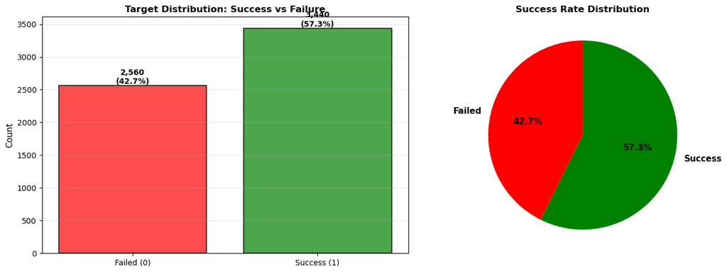

```
💡 What This Chart Tells Us:
   - Dataset is relatively balanced (57.3% success rate)
   - Not severely imbalanced, so accuracy is a reasonable metric
   - Baseline (always predict majority class) = 57.3%
   - Our model must beat this baseline to be useful
```

```python
plot_target_distribution(df)
```

### 3. Analyze Feature Distributions

Let's see how numerical features differ between successful and failed innovations.

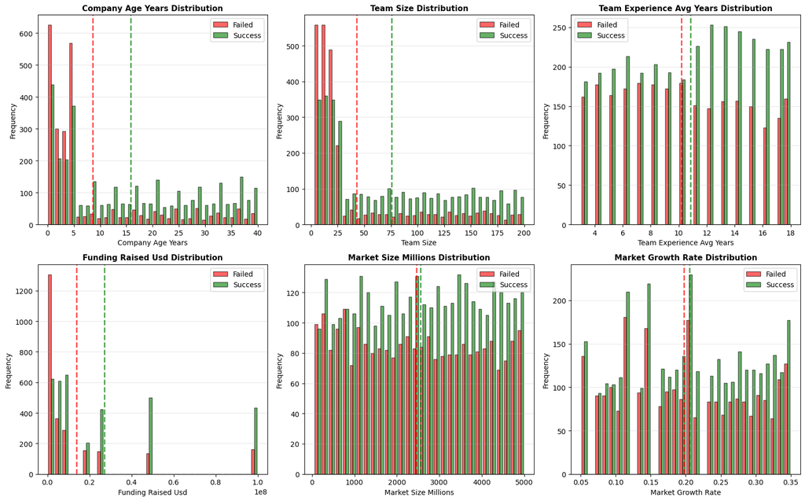

```
💡 What This Chart Tells Us:
   - Green = successful innovations, Red = failed innovations
   - Dashed lines show mean values for each class
   - Look for separation between red and green distributions
   - Better separation = feature is more predictive
```

```python
analyze_feature_distributions(df)
```

### 4. Prepare Features and Split Data

```python
X, y, feature_cols, df_prep = prepare_features(df)
```

```
Feature Engineering Steps:
----------------------------------------
✓ Using 7 numerical features
✓ Encoded 3 categorical variables → 5 binary features

✓ Total features: 12
✓ Samples: 6,000
```

### 5. Feature Correlation Analysis

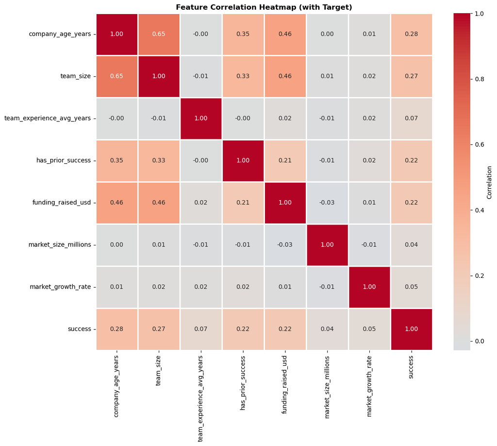

```
💡 Top Correlations with Success:
company_age_years            0.283836
team_size                    0.271833
funding_raised_usd           0.218116
has_prior_success            0.215316
team_experience_avg_years    0.072395
Name: success, dtype: float64

💡 Negative Correlations (inverse relationship):
funding_raised_usd           0.218116
has_prior_success            0.215316
team_experience_avg_years    0.072395
market_growth_rate           0.046734
market_size_millions         0.035776
Name: success, dtype: float64

   - Positive correlation: higher value → higher success probability
   - Negative correlation: higher value → lower success probability
```

```python
plot_correlation_heatmap(df_prep, feature_cols)
```

### 6. Train-Test Split

**Why split?** We need to test the model on data it hasn't seen during training to get an honest assessment of performance.

```python
X_train, X_test, y_train, y_test = split_data(X, y, test_size=0.2)
```

```
Data Split:
----------------------------------------
Training set: 4,800 samples (80%)
Test set: 1,200 samples (20%)

Training success rate: 57.3%
Test success rate: 57.3%

✓ Stratified split maintains class balance
```

### 7. Train Random Forest

**Random Forest** is an ensemble of decision trees that:

- Builds multiple trees on random subsets of data and features
- Each tree "votes" on the prediction
- Majority vote wins (reduces overfitting)
- Handles non-linear relationships well
- Provides feature importance

```python
rf_model = train_random_forest(X_train, y_train, n_estimators=100, max_depth=10)
```

```
Training Random Forest...
----------------------------------------
Parameters: n_estimators=100, max_depth=10
```

```
✓ Model trained successfully
```

### 8. Evaluate Random Forest

```python
rf_results = evaluate_model(rf_model, X_test, y_test, model_name='Random Forest')
```

```
================================================================================
RANDOM FOREST PERFORMANCE
================================================================================

Accuracy:  70.4%  (correct predictions / total predictions)
Precision: 71.8%  (true positives / predicted positives)
Recall:    79.8%  (true positives / actual positives)
F1-Score:  75.6%  (harmonic mean of precision and recall)
ROC-AUC:   0.758  (area under ROC curve, 0.5=random, 1.0=perfect)

Classification Report:
```

```
              precision    recall  f1-score   support

      Failed       0.68      0.58      0.63       512
     Success       0.72      0.80      0.76       688

    accuracy                           0.70      1200
   macro avg       0.70      0.69      0.69      1200
weighted avg       0.70      0.70      0.70      1200

================================================================================
```

### 9. Confusion Matrix

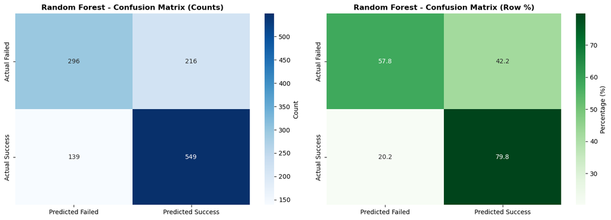

```
💡 Confusion Matrix Interpretation:
   - True Negatives (TN): 296 - Correctly predicted failures
   - False Positives (FP): 216 - Predicted success, actually failed
   - False Negatives (FN): 139 - Predicted failure, actually succeeded
   - True Positives (TP): 549 - Correctly predicted successes
```

```python
plot_confusion_matrix(y_test, rf_results['predictions'], model_name='Random Forest')
```

### 10. Feature Importance Analysis

**Feature Importance** shows which variables the model relies on most for predictions.

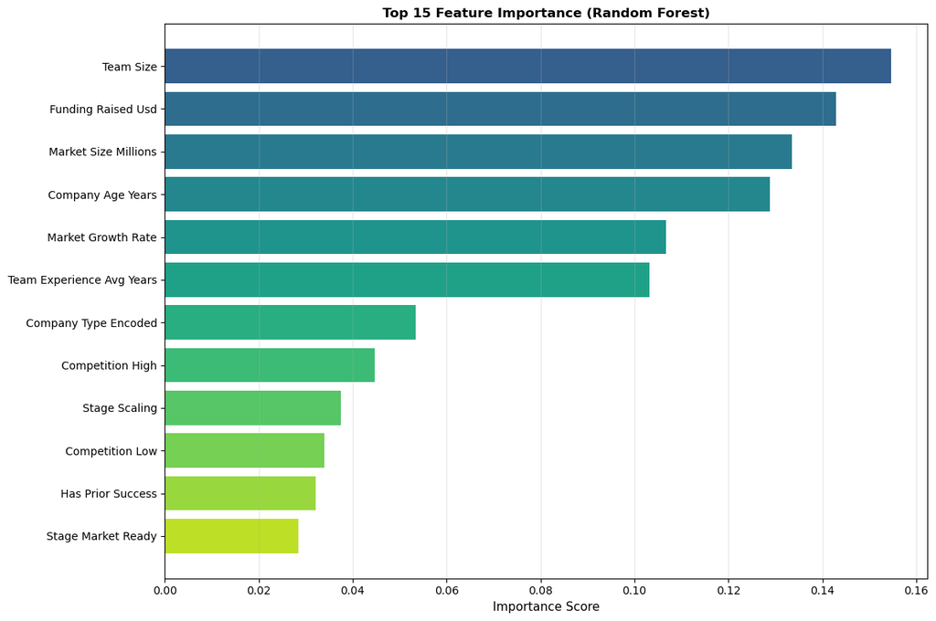

```
💡 Top 10 Most Important Features:
   team_size                      0.1547
   funding_raised_usd             0.1429
   market_size_millions           0.1336
   company_age_years              0.1289
   market_growth_rate             0.1067
   team_experience_avg_years      0.1033
   company_type_encoded           0.0533
   competition_high               0.0447
   stage_scaling                  0.0375
   competition_low                0.0340

💡 Feature Importance Interpretation:
   - Higher importance = feature contributes more to predictions
   - Based on reduction in impurity (Gini) at each split
   - Sum of all importances = 1.0
```

```python
importance_df = plot_feature_importance(rf_model, feature_cols, top_n=15)
```

### 11. Train Logistic Regression (Baseline)

**Logistic Regression** is a linear model:

- Assumes linear relationships between features and log-odds
- Simple and interpretable
- Fast to train
- Good baseline for comparison

```python
lr_model, lr_scaler = train_logistic_regression(X_train, y_train)
```

```
Training Logistic Regression (Baseline)...
----------------------------------------
✓ Model trained successfully
```

### 12. Evaluate Logistic Regression

```python
lr_results = evaluate_model(lr_model, X_test, y_test, model_name='Logistic Regression', scaler=lr_scaler)
```

```
================================================================================
LOGISTIC REGRESSION PERFORMANCE
================================================================================

Accuracy:  71.1%  (correct predictions / total predictions)
Precision: 73.3%  (true positives / predicted positives)
Recall:    77.9%  (true positives / actual positives)
F1-Score:  75.5%  (harmonic mean of precision and recall)
ROC-AUC:   0.777  (area under ROC curve, 0.5=random, 1.0=perfect)

Classification Report:
              precision    recall  f1-score   support

      Failed       0.68      0.62      0.65       512
     Success       0.73      0.78      0.76       688

    accuracy                           0.71      1200
   macro avg       0.70      0.70      0.70      1200
weighted avg       0.71      0.71      0.71      1200

================================================================================
```

### 13. Train XGBoost (Advanced)

**XGBoost** (eXtreme Gradient Boosting):

- Builds trees sequentially, each correcting previous errors
- Often achieves state-of-the-art results
- More complex than Random Forest
- Requires careful tuning

```python
xgb_model = train_xgboost(X_train, y_train)

if xgb_model is not None:
    xgb_results = evaluate_model(xgb_model, X_test, y_test, model_name='XGBoost')
else:
    print("Skipping XGBoost evaluation (not installed)\n")
```

```
Training XGBoost...
----------------------------------------
Parameters: n_estimators=100, max_depth=6, learning_rate=0.1
```

```
✓ Model trained successfully

================================================================================
XGBOOST PERFORMANCE
================================================================================

Accuracy:  69.6%  (correct predictions / total predictions)
Precision: 71.6%  (true positives / predicted positives)
Recall:    77.8%  (true positives / actual positives)
F1-Score:  74.6%  (harmonic mean of precision and recall)
ROC-AUC:   0.739  (area under ROC curve, 0.5=random, 1.0=perfect)

Classification Report:
              precision    recall  f1-score   support

      Failed       0.66      0.59      0.62       512
     Success       0.72      0.78      0.75       688

    accuracy                           0.70      1200
   macro avg       0.69      0.68      0.68      1200
weighted avg       0.69      0.70      0.69      1200

================================================================================
```

### 14. Compare Models: ROC Curves

**ROC Curve** (Receiver Operating Characteristic) shows the tradeoff between:

- **True Positive Rate** (Sensitivity/Recall): Of actual successes, how many did we catch?
- **False Positive Rate**: Of actual failures, how many did we mistakenly predict as success?

**AUC** (Area Under Curve) summarizes overall model quality:

- 0.5 = random guessing
- 1.0 = perfect classifier
- 0.7-0.8 = acceptable
- 0.8-0.9 = excellent
- > 0.9 = outstanding

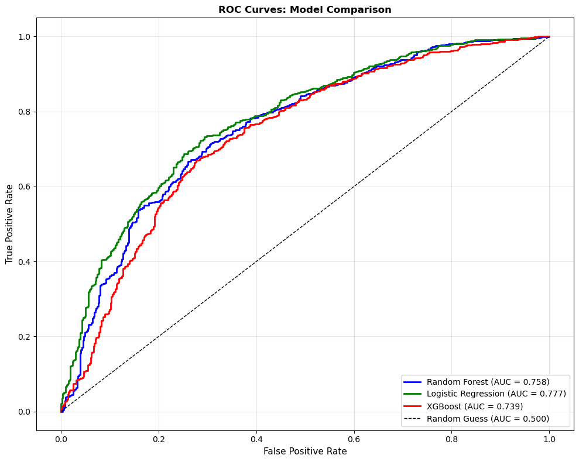

```
💡 ROC Curve Interpretation:
   - ROC = Receiver Operating Characteristic
   - Shows tradeoff between True Positive Rate and False Positive Rate
   - AUC (Area Under Curve) = overall model quality metric
   - AUC = 0.5: Random guessing | AUC = 1.0: Perfect classifier
   - Higher curve = better model
```

```python
models_data = {
    'Random Forest': rf_results,
    'Logistic Regression': lr_results
}

if xgb_model is not None:
    models_data['XGBoost'] = xgb_results

plot_roc_curves(models_data, y_test)
```

### 15. Precision-Recall Curves

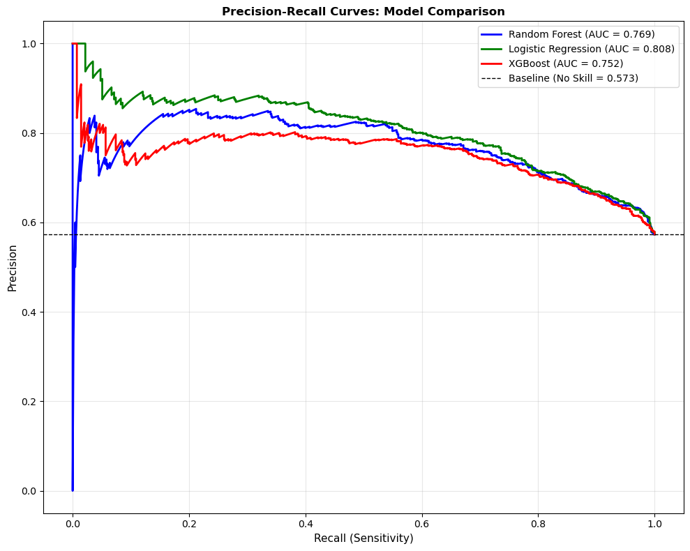

```
💡 Precision-Recall Curve Interpretation:
   - Useful for imbalanced datasets
   - Precision: Of predicted successes, how many were correct?
   - Recall: Of actual successes, how many did we find?
   - Higher curve = better model
```

```python
plot_precision_recall_curves(models_data, y_test)
```

### 16. Model Comparison: All Metrics

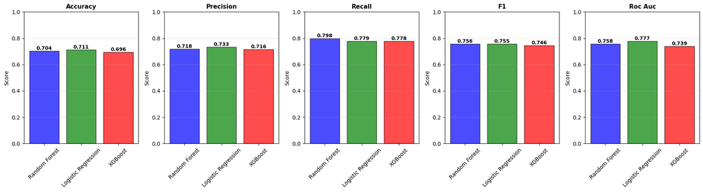

```
💡 Model Comparison Summary:

Random Forest:
  accuracy    : 0.704
  precision   : 0.718
  recall      : 0.798
  f1          : 0.756
  roc_auc     : 0.758

Logistic Regression:
  accuracy    : 0.711
  precision   : 0.733
  recall      : 0.779
  f1          : 0.755
  roc_auc     : 0.777

XGBoost:
  accuracy    : 0.696
  precision   : 0.716
  recall      : 0.778
  f1          : 0.746
  roc_auc     : 0.739
```

```python
compare_models_metrics(models_data)
```

### 17. Prediction Probability Distributions

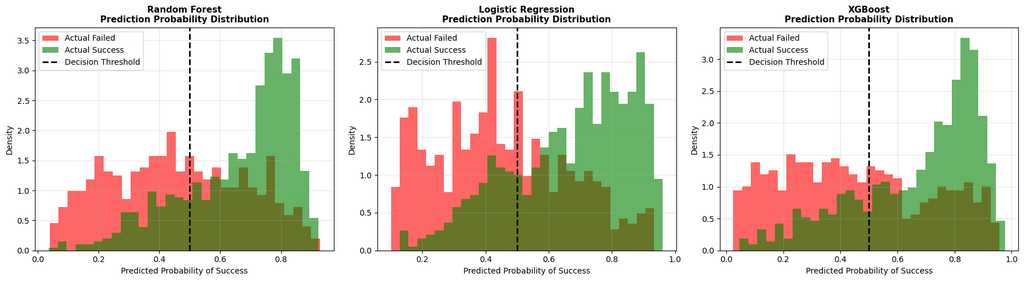

```
💡 Probability Distribution Interpretation:
   - Good separation: failed (red) peaks near 0, success (green) peaks near 1
   - Overlap in middle: model is uncertain for these cases
   - Default threshold = 0.5 (can be adjusted based on business needs)
```

```python
plot_prediction_distributions(models_data, y_test)
```

### 18. Learning Curves

**Learning Curves** help diagnose:

- **Overfitting**: Training score much higher than validation score
- **Underfitting**: Both scores are low
- **Good fit**: Curves converge at high performance
- **Need more data**: Validation score still improving

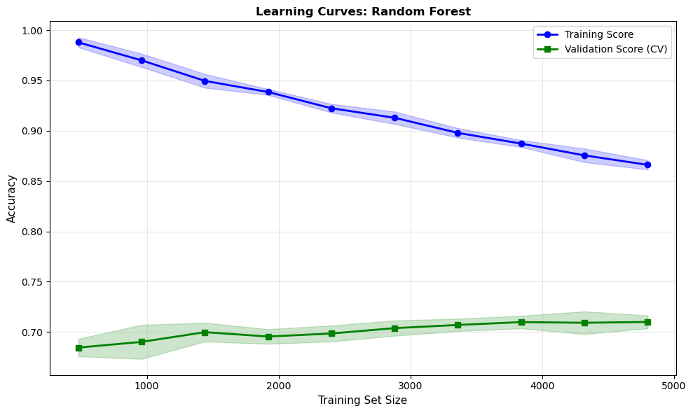

```
💡 Learning Curve Interpretation:
   - Training score > Validation score → Overfitting (memorizing training data)
   - Both scores low → Underfitting (model too simple)
   - Curves converge → Good fit
   - More data helps when curves haven't plateaued
```

```python
plot_learning_curves(rf_model, X, y, model_name='Random Forest')
```

### 19. Misclassification Analysis

```python
analyze_misclassifications(rf_model, X_test, y_test, feature_cols, n_examples=5)
```

```
================================================================================
MISCLASSIFICATION ANALYSIS
================================================================================

Total misclassifications: 355 (29.6% of test set)
False Positives: 216 (predicted success, actually failed)
False Negatives: 139 (predicted failure, actually succeeded)
```

```
Top 5 Most Confident Errors:
--------------------------------------------------------------------------------

Error 1: Actual=1, Predicted Prob=0.036
  Key features:
    company_age_years             : 4.0
    team_size                     : 21.0
    team_experience_avg_years     : 6.0
    has_prior_success             : 0.0
    funding_raised_usd            : 500000.0

Error 2: Actual=0, Predicted Prob=0.930
  Key features:
    company_age_years             : 21.0
    team_size                     : 32.0
    team_experience_avg_years     : 18.0
    has_prior_success             : 1.0
    funding_raised_usd            : 50000000.0

Error 3: Actual=1, Predicted Prob=0.073
  Key features:
    company_age_years             : 4.0
    team_size                     : 24.0
    team_experience_avg_years     : 6.0
    has_prior_success             : 0.0
    funding_raised_usd            : 100000.0

Error 4: Actual=0, Predicted Prob=0.924
  Key features:
    company_age_years             : 13.0
    team_size                     : 108.0
    team_experience_avg_years     : 14.0
    has_prior_success             : 0.0
    funding_raised_usd            : 5000000.0

Error 5: Actual=1, Predicted Prob=0.083
  Key features:
    company_age_years             : 1.0
    team_size                     : 13.0
    team_experience_avg_years     : 7.0
    has_prior_success             : 0.0
    funding_raised_usd            : 1000000.0

================================================================================
```

### 20. Key Insights and Recommendations

```python
print_key_insights(models_data, importance_df)
```

[output not shown]

## Summary

You've now completed a comprehensive supervised learning analysis!

**Next Steps:**

- **02_unsupervised_learning.ipynb**: Discover innovation archetypes through clustering
- **03_nlp_analysis.ipynb**: Analyze innovation descriptions with NLP
- **04_neural_networks.ipynb**: Build deep learning models
- **05_genai.ipynb**: Generate new innovation pitches with AI